# scikit_classifier

## scikit-learn

### DecisionTreeClassifier

**Descripion:** Scikit-learn is a popular open-source machine learning library for Python. It provides a wide range of tools for various machine learning tasks such as classification, regression, clustering, and dimensionality reduction. Scikit-learn also includes tools for data preprocessing, model selection, and evaluation, making it a comprehensive and user-friendly library for machine learning in Python.

**Information:** Altough the catboost model provided by seznam.cz is essentially suitable for sklearn.DecisionRegressor instance, it is worth mentioning to look at options to visualize a classifier model within the library sklearn. Therefore a sklearn.DecisionTreeClassifier instance is trained by validation data from seznam.cz to provide classifier visualizations we can inspire of.

```python
import sys
sys.path.append('../../../utils')
import data_funcs as utils
```

```python
X,y,features = utils.get_validation_data('../../../data/validation-set.tsv')
```

### Getting the sklearn.DecisionTreeClassifier Instance

**Description:** Since the library sklearn is not directly compatible with decision trees from gradient boosting machines made by catboost, we will use sklearn native trained instance.

```python
from sklearn.tree import DecisionTreeClassifier
```

```python
clf = DecisionTreeClassifier(max_depth=3);
clf.fit(X,y);
```

**Information:** For further visualizations fit() function to the model needs to be runned.

### Text Representation of the Decision Tree

```python
from sklearn import tree
```

```python
text_representation = tree.export_text(clf)
print(text_representation)
```

```
|--- feature_3 <= 0.50
|   |--- feature_23 <= 58.62
|   |   |--- feature_29 <= 1.50
|   |   |   |--- class: 0.0
|   |   |--- feature_29 >  1.50
|   |   |   |--- class: 1.0
|   |--- feature_23 >  58.62
|   |   |--- feature_21 <= 0.47
|   |   |   |--- class: 1.0
|   |   |--- feature_21 >  0.47
|   |   |   |--- class: 1.0
|--- feature_3 >  0.50
|   |--- feature_17 <= 0.10
|   |   |--- feature_12 <= 130.27
|   |   |   |--- class: 0.0
|   |   |--- feature_12 >  130.27
|   |   |   |--- class: 0.0
|   |--- feature_17 >  0.10
|   |   |--- feature_27 <= 0.17
|   |   |   |--- class: 1.0
|   |   |--- feature_27 >  0.17
|   |   |   |--- class: 0.0
```

**Description:** Text representation of DecisionTreeClassifier is except of 'leaf values' the same as DecisionTreeRegressor's one.

```python
with open("visualizations/clf_text_representation.log", "w") as fout:
    fout.write(text_representation)
```

### Plot with sklearn.tree.plot_tree Method

```python
from matplotlib import pyplot as plt
```

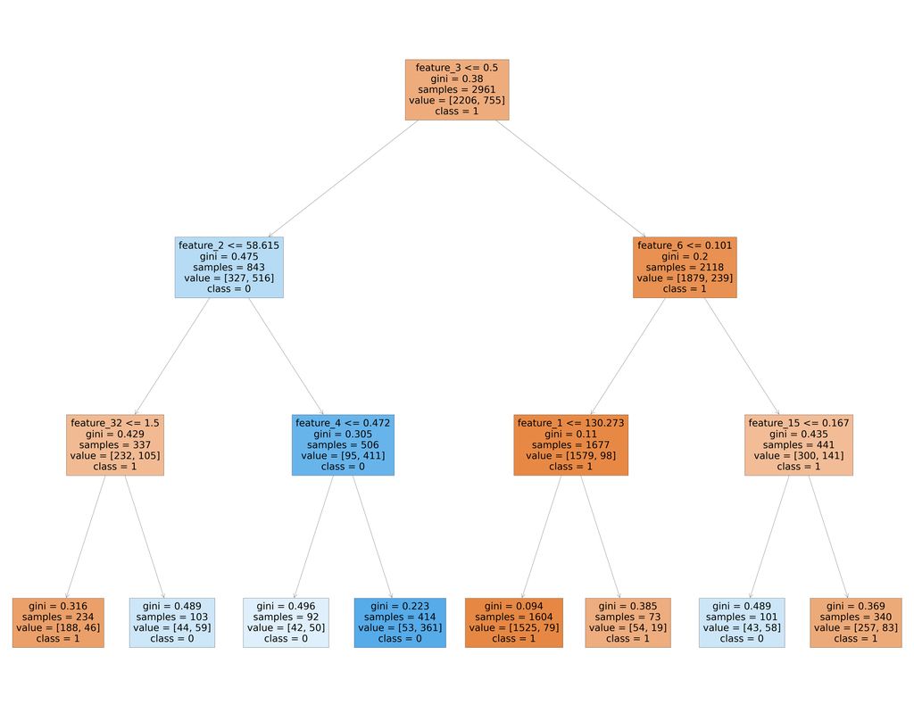

```python
fig = plt.figure(figsize=(100,80))
_ = tree.plot_tree(clf,
                   feature_names=features,
                   class_names=['1', '0'],
                   filled=True)
```

**Description:** General decision tree visualization, non-colored nodes have no majority prediction. The more is the color of the node satured the more samples of one specific class have majority over others.. Values are described in internal nodes as well.

```python
fig.savefig("visualizations/clf_sklearn_plot_tree.png")
```

#### graphviz Plot

**Description:** For a better readability we can also visualize the tree using graphviz library preserving the same inforamtion with a variety of aesthetic options, including coloring nodes by ther class and using explicit variable and class names if desired.

```python
import graphviz
```

```python
dot_data = tree.export_graphviz(clf,
                                out_file=None,
                                feature_names=features,
                                class_names=['1', '0'],
                                filled=True)
```

```python
graph = graphviz.Source(dot_data, format="png")
graph
```

[figure not shown]

```python
graph.render("visualizations/clf_graphviz");
```